[OHI British Columbia](http://www.ohibc.org/) | [OHI Science](http://ohi-science.org) | [Citation policy](https://github.com/OHI-Science/ohiprep/releases)

# OHIBC: CW chemical layers prep

Compiled on Wed Sep 7 15:50:12 2016 by ohara

# 1 Summary

These data were prepared for the global 2016 assessment.

The Status of chemical pollution was measured via four global datasets: land-based organic from agricultural pesticide use (reported to FAO), inorganic pollution from runoff from impervious surfaces, and ocean-based pollution from commercial shipping and ports.

The shipping, ports and harbors, and inorganic pollution have not changed over time. However, the organic (pesticide) pollution is updated yearly, with the most recent data from 2013.

The shipping, ports and harbors, and inorganic pollution data are located [here](https://knb.ecoinformatics.org/#view/doi:10.5063/F1S180FS).

The most recent land-based organic data is on a NCEAS server: Mazu:marine_threats/impact_layers_2013_redo/impact_layers/work/land_based/before_2007/raw_global_results/

# 2 Data Source

**Reference**: [Eriksen et al. 2014](http://journals.plos.org/plosone/article?id=10.1371/journal.pone.0111913)

**Downloaded**: December 10, 2014 directly from authors

**Native Data Resolution**:

**Values**: Count (number/km2) and weight (g/km2) across 4 size classes

**Time Range**: N/A

**Format**: GeoTIFF

# 3 Methods

## 3.1 Process individual layers

### 3.1.1 Pesticides

These data cover a time period of 2002-2013. Each layer is read in, reprojected to BC Albers at 1 km resolution and clipped to OHIBC EEZ. Then each layer is log-transformed (log(x+1)) and then rescaled to the 99.99%ile (rescaled) value found across all years to create layer values from zero to 1.

#### 3.1.1.1 Read in data

#### 3.1.1.2 Log Transform pesticides

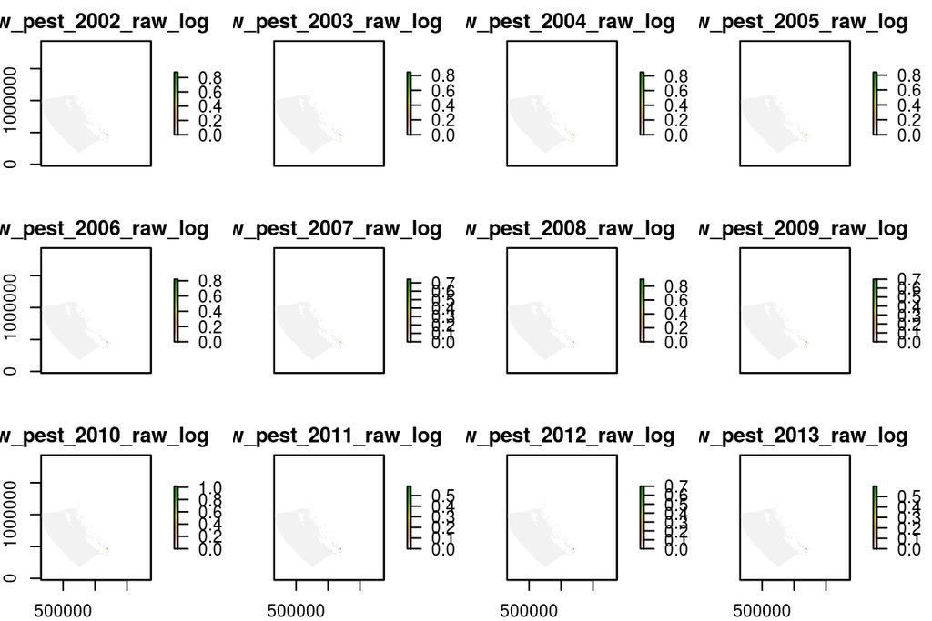

#### 3.1.1.3 Rescale pesticides to 99.99th quantile

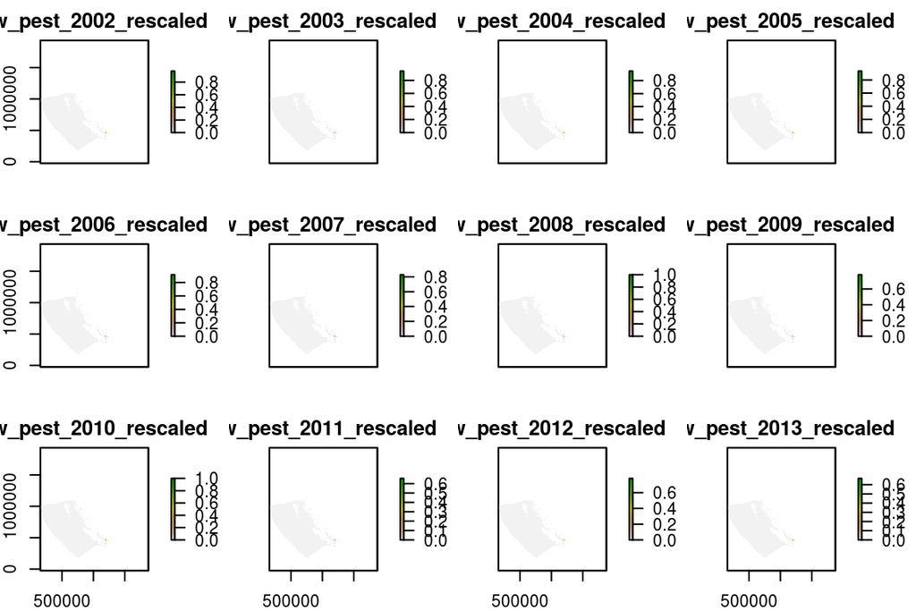

### 3.1.2 Ocean pollution

Data are already log-transformed and normalized. Here we reproject and clip to just OHIBC EEZ, and rescale to a new max value based on highest pressure within OHIBC EEZ.

### 3.1.3 Land-based inorganics

Data are already log-transformed and normalized. Here we reproject and clip to just OHIBC EEZ, and rescale to a new max value based on highest pressure within OHIBC EEZ.

## 3.2 Combine layers (sum method)

Because one layer (pesticides) is calculated for each year from 2002-2013, we will perform this as a loop: stack each year of pesticides with the static layers for inorganic and ocean pollution, and sum for each year, saving each as a separate raster by year.